# **secr** simulations Mt

Murray Efford

2024-06-14

# Temporal variation in detection parameters Mt

The simulations described here are part of a series documenting the effect of breaching assumptions of spatially explicit capture–recapture models.

Temporal variation is generally not thought to be a problem for SECR estimates of density (Sollmann 2024). These simulations extend the empirical basis for the conclusion.

## Problem description

The SECR null model assumes $\lambda_0$ and $\sigma$ are constant over occasions. We vary these parameters and examine the resulting estimates from a null model.

## Settings

Square grid of 64 binary proximity detectors at spacing $c = 2\sigma$.

The same conditions were used for simulation and fitting.

| Parameter | Value(s) |
| --- | --- |
| detectfn | ‘HHN’ |
| D | $12.5 \sigma^{-2}$ |
| lambda0 | 0.1 |
| sigma | c/2 |
| noccasions | 10 |
| buffer | $4\sigma$ |
| nx | 32 |

## Package version, date and platform

```r
source('../setup.R')
runsim  <- FALSE
figures <- TRUE
cache   <- TRUE
nrepl   <- 200
metadata(runsim) # if FALSE picks up saved metadata.RDS
```

```
## R version 4.3.2 (2023-10-31)
## Platform   x86_64-pc-linux-gnu (64-bit)
## Running    CentOS Linux 7 (Core)
## secr       4.6.7 2024-05-18
## secrdesign 2.9.2 2024-05-18
## Threads    40
## Run        Tue Jun 11 21:51:52 2024
```

## Simulation code

### Custom function to simulate capture histories

We vary the time-specific detection parameters at each replicate, using a log-normal random variate to keep values positive.

```r
simCV.capthist <- function (detectpar = list(), CVlambda0 = 0, CVsigma =0, ...)
{
    nocc <- list(...)$noccasions
    if (CVlambda0>0)
        detectpar$lambda0 <- secr::rlnormCV(nocc, detectpar$lambda0, CVlambda0)
    if (CVsigma>0)
        detectpar$sigma <- secr::rlnormCV(nocc, detectpar$sigma, CVsigma)
    sim.capthist(detectpar = detectpar, ...)
}
```

Visualising the parameter distributions:

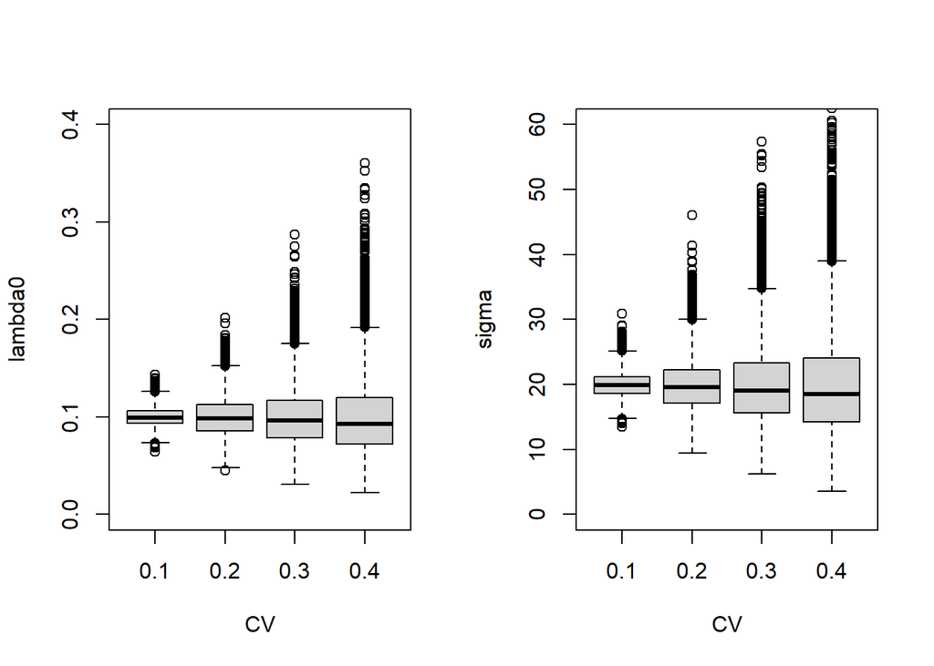

```r
par(mfrow=c(1,2))
cvlevels <- c(0.1, 0.2, 0.3, 0.4)
lam0 <- lapply(cvlevels, secr::rlnormCV, n = 10000, mean = 0.1)
sig <- lapply(cvlevels, secr::rlnormCV, n = 10000, mean = 20)
boxplot(lam0, ylim=c(0,0.4), names = cvlevels, xlab = 'CV', ylab = 'lambda0')
boxplot(sig, ylim=c(0,60), names = cvlevels, xlab = 'CV', ylab = 'sigma')
```

### Define Mt scenarios

```r
grid <- make.grid(nx = 8, ny = 8, spacing = 40, detector = "proximity")
detarg <- c(expand.arg(CVlambda0 = seq(0,0.4,0.1), CVsigma = 0),
            expand.arg(CVlambda0 = 0, CVsigma = seq(0.1,0.4,0.1)))
fitarg <- expand.arg(detectfn = 'HHN', model = c(lambda0 ~ 1,lambda0 ~ t))
# Mean lambda0 and sigma in scenario (used as reference for RB etc.)
# CV is provided by detarg and used by simCV.capthist
# ignore model ~t for now
scen <- make.scenarios(D = 12.5, noccasions = 10, detectfn = 14,
    lambda0 = 0.1, sigma = 20, detindex = 1:length(detarg), fitindex = 1)
```

```r
scenarioSummary(scen, grid)
```

```
##   scenario trapsindex noccasions nrepeats    D lambda0 sigma detectfn     En     Er     Em    En2
## 1        1          1         10        1 12.5     0.1    20       14 110.03 86.116 55.021 40.795
## 2        2          1         10        1 12.5     0.1    20       14 110.03 86.116 55.021 40.795
## 3        3          1         10        1 12.5     0.1    20       14 110.03 86.116 55.021 40.795
## 4        4          1         10        1 12.5     0.1    20       14 110.03 86.116 55.021 40.795
## 5        5          1         10        1 12.5     0.1    20       14 110.03 86.116 55.021 40.795
## 6        6          1         10        1 12.5     0.1    20       14 110.03 86.116 55.021 40.795
## 7        7          1         10        1 12.5     0.1    20       14 110.03 86.116 55.021 40.795
## 8        8          1         10        1 12.5     0.1    20       14 110.03 86.116 55.021 40.795
## 9        9          1         10        1 12.5     0.1    20       14 110.03 86.116 55.021 40.795
##      esa CF rotRSE rotRSEB arrayN arrayspace arrayspan saturation detperHR.median       k
## 1 8.8021  1 0.1078  0.0858     64          2    19.799    0.26959               4 0.70711
## 2 8.8021  1 0.1078  0.0858     64          2    19.799    0.26959               4 0.70711
## 3 8.8021  1 0.1078  0.0858     64          2    19.799    0.26959               4 0.70711
## 4 8.8021  1 0.1078  0.0858     64          2    19.799    0.26959               4 0.70711
## 5 8.8021  1 0.1078  0.0858     64          2    19.799    0.26959               4 0.70711
## 6 8.8021  1 0.1078  0.0858     64          2    19.799    0.26959               4 0.70711
## 7 8.8021  1 0.1078  0.0858     64          2    19.799    0.26959               4 0.70711
## 8 8.8021  1 0.1078  0.0858     64          2    19.799    0.26959               4 0.70711
## 9 8.8021  1 0.1078  0.0858     64          2    19.799    0.26959               4 0.70711
```

### Check empirical CV of counts per occasion

```r
Mtraw <- run.scenarios(
    nrepl       = nrepl,
    scenarios   = scen,
    trapset     = grid,
    det.args    = detarg,
    CH.function = "simCV.capthist",
    fit         = FALSE,
    seed        = 12345,
    extractfn   = identity)
# average CV(detections) for each scenario
cvt <- function(y) CV(apply(y,2,sum))  # temporal CV(detections)
CVmat <- sapply(Mtraw$output, function (x) sapply(x, cvt))
apply(CVmat,2,mean)
```

```
##       1       2       3       4       5       6       7       8       9
## 0.21378 0.24222 0.28867 0.35738 0.42706 0.29182 0.43804 0.61380 0.78757
```

### Run Mt simulations

```r
Mtsims <- run.scenarios(
    nrepl       = nrepl,
    scenarios   = scen,
    trapset     = grid,
    det.args    = detarg,
    CH.function = "simCV.capthist",
    fit         = TRUE,
    fit.args    = fitarg,
    seed        = 12345)
saveRDS(Mtsims, file = 'Mtsims.RDS')
```

Mtsims completed with 200 replicates in 21.6 minutes.

## Results

```
## Density
##   CVlambda0 CVsigma true.D nvalid   EST   seEST         RB     seRB    RSE  RMSE   rRMSE   COV
## 1       0.0     0.0   12.5    200 12.59 0.08899  0.0070265 0.007120 0.1096 1.258 0.10068 0.970
## 2       0.1     0.0   12.5    200 12.67 0.09784  0.0137742 0.007828 0.1093 1.391 0.11128 0.935
## 3       0.2     0.0   12.5    200 12.50 0.09859 -0.0001595 0.007887 0.1099 1.391 0.11126 0.955
## 4       0.3     0.0   12.5    200 12.45 0.09417 -0.0038770 0.007534 0.1114 1.329 0.10635 0.950
## 5       0.4     0.0   12.5    200 12.62 0.08749  0.0092668 0.006999 0.1102 1.240 0.09917 0.970
## 6       0.0     0.1   12.5    200 12.48 0.09479 -0.0012609 0.007583 0.1097 1.337 0.10698 0.950
## 7       0.0     0.2   12.5    200 12.64 0.09661  0.0110474 0.007729 0.1080 1.370 0.10958 0.960
## 8       0.0     0.3   12.5    200 12.51 0.09998  0.0006086 0.007999 0.1088 1.410 0.11284 0.945
## 9       0.0     0.4   12.5    200 12.66 0.09389  0.0129181 0.007512 0.1062 1.334 0.10675 0.955
## lambda0
##   CVlambda0 CVsigma true.lambda0 nvalid     EST    seEST        RB    seRB    RSE    RMSE  rRMSE   COV
## 1       0.0     0.0          0.1    200 0.10108 0.001115  0.010830 0.01115 0.1497 0.01576 0.1576 0.935
## 2       0.1     0.0          0.1    200 0.10095 0.001070  0.009524 0.01070 0.1494 0.01512 0.1512 0.955
```

[output cut: 18 more lines]

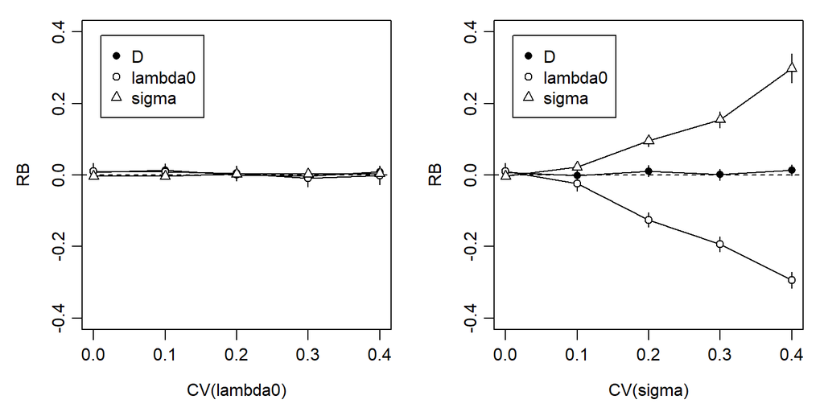

Relative bias of parameter estimates from null model given temporal variation in lambda0 or sigma

## Interpretation

Estimates of density from the null model are indeed robust to temporal variation in $\lambda_0$ or $\sigma$, but variation in $\sigma$ drives complementary bias in $\hat \lambda_0$ and $\hat \sigma$

## One-off

Run this code to obtain results for a single scenario (here CV(lambda0) = 1). Re-uses code in chunk ‘Mt capthist’.

```r
simCV.capthist <- function (detectpar = list(), CVlambda0 = 0, CVsigma =0, ...)
{
    nocc <- list(...)$noccasions
    if (CVlambda0>0)
        detectpar$lambda0 <- secr::rlnormCV(nocc, detectpar$lambda0, CVlambda0)
    if (CVsigma>0)
        detectpar$sigma <- secr::rlnormCV(nocc, detectpar$sigma, CVsigma)
    sim.capthist(detectpar = detectpar, ...)
}
grid <- make.grid(nx = 8, ny = 8, spacing = 40, detector = "proximity")
detarg <- list(detectpar = list(CVlambda0 = 1, CVsigma = 0))
fitarg <- list(detectfn = 'HHN')  # null model
scen <- make.scenarios(D = 12.5, noccasions = 10, detectfn = 14, lambda0 = 0.1, sigma = 20)
oneoff <- run.scenarios(nrepl = 100, scen, trapset = grid, det.args = detarg,
    CH.function = "simCV.capthist", fit = TRUE, fit.args = fitarg, seed = 12345)
summary(oneoff)
```